# Módulo 4 — RBC: momentos, Slutsky y el reto de México

**Curso complementario · puremacro**

### Objetivos de aprendizaje

Al terminar esta lección podrás:

1. Construir la **tabla de momentos del ciclo** (volatilidades relativas, comovimiento, persistencia) con el filtro de **Hamilton** sobre datos reales de EE. UU.
2. Entender el **efecto Slutsky**: una media móvil de ruido blanco fabrica un ciclo que a simple vista no se distingue del ciclo real.
3. Contrastar el RBC canónico con el **reto mexicano**, enunciado como toca: no que $\sigma_c/\sigma_y$ cruce el $1$ —con la convención canónica del curso **no lo cruza**— sino que esté *tan pegado* al $1$ ($0.96$) cuando el modelo cerrado entrega $\approx0.44$. Es un fallo de **magnitud**, no de signo. Y repasar sus tres salidas: choques de productividad más persistentes ($\sigma_a$), choques a la **tendencia**, y la **tasa de interés país** ($q_t$).

Todo corre en Python puro sobre tu **instalación local** de `puremacro` (`pip install puremacro`): sin conexión y sin costo.

## 1. Los momentos del ciclo económico

El modelo de **ciclos económicos reales** (RBC) se juzga por su capacidad de reproducir un puñado de *momentos*: la **desviación estándar** del producto, las **volatilidades relativas** de sus componentes ($\sigma_x/\sigma_y$), el **comovimiento** de cada componente con el producto y la **persistencia** (autocorrelación de primer orden) del ciclo. Antes de calcularlos hay que separar tendencia y ciclo; aquí usamos el filtro de **Hamilton (2018)**, que proyecta $y_{t+h}$ sobre sus rezagos recientes y toma el residuo como ciclo (evita las dinámicas espurias del filtro HP).

Datos reales del *bundle*: `GDPC1` (PIB real) y `GPDIC1` (inversión **privada bruta interna**, que incluye la variación de existencias), ambos trimestrales, 1947Q1–2026Q1.

```python
from puremacro.cycles import hamilton_filter
from puremacro.data import hp_filter
from puremacro.spectral import business_cycle_band_power

y = pd.read_csv(DATA / "GDPC1.csv")
inv = pd.read_csv(DATA / "GPDIC1.csv")
panel = y.merge(inv, on="observation_date")

log_y = 100.0 * np.log(panel["GDPC1"].to_numpy())     # log-PIB en puntos porcentuales
log_i = 100.0 * np.log(panel["GPDIC1"].to_numpy())    # log-inversión

cyc_y, _ = hamilton_filter(log_y)   # (ciclo, tendencia); las primeras h+p-1 obs son NaN
cyc_i, _ = hamilton_filter(log_i)

ok = ~np.isnan(cyc_y) & ~np.isnan(cyc_i)              # descartar el calentamiento del filtro
cyc_y, cyc_i = cyc_y[ok], cyc_i[ok]
```

### La tabla de momentos

Sobre el ciclo de Hamilton: volatilidad absoluta del producto, volatilidad relativa de la inversión ($\sigma_i/\sigma_y$), su comovimiento con el producto, la persistencia del PIB y la cuota de varianza que cae en la banda de negocios de 6–32 trimestres.

```python
sigma_y = cyc_y.std()
rel_vol_inv = cyc_i.std() / sigma_y
comov_inv = np.corrcoef(cyc_i, cyc_y)[0, 1]
persist_y = np.corrcoef(cyc_y[1:], cyc_y[:-1])[0, 1]
band_share = business_cycle_band_power(cyc_y)

print(f"observaciones usadas                       = {cyc_y.size}")
print(f"sigma_y  (desv. est. del ciclo del PIB, %) = {sigma_y:.2f}")
print(f"sigma_i / sigma_y  (volatilidad relativa)  = {rel_vol_inv:.2f}")
print(f"comovimiento  corr(inversión, PIB)         = {comov_inv:.2f}")
print(f"persistencia  corr(y_t, y_t-1)             = {persist_y:.2f}")
print(f"cuota espectral en banda 6-32 trimestres   = {band_share:.2f}")

# Hechos canónicos: la inversión es mucho más volátil que el producto y muy procíclica.
assert rel_vol_inv > 2.0
assert comov_inv > 0.6
assert 0.0 < band_share <= 1.0
```

```
observaciones usadas                       = 306
sigma_y  (desv. est. del ciclo del PIB, %) = 3.25
sigma_i / sigma_y  (volatilidad relativa)  = 3.81
comovimiento  corr(inversión, PIB)         = 0.82
persistencia  corr(y_t, y_t-1)             = 0.89
cuota espectral en banda 6-32 trimestres   = 0.63
```

**Lectura.** La inversión es $3.8$ veces más volátil que el producto y fuertemente procíclica ($0.82$); el producto es muy persistente ($0.89$). Estos son justo los blancos que un RBC bien calibrado debe acertar.

*Aviso de comparabilidad con el mazo A4.* La tabla del mazo reporta $\sigma_i/\sigma_y=1.98$ porque está construida sobre el **agregado unisectorial**, y su nota anuncia $\sim3$ con la definición estándar de **inversión fija privada**. Aquí sale $3.8$ porque `GPDIC1` es inversión privada bruta **con existencias**, y la variación de existencias es el componente más volátil de la contabilidad nacional. Las tres cifras son correctas: son tres series distintas. Es exactamente el punto de la ficha de medición.

El componente que *falta* aquí es el **consumo**: en EE. UU. es más suave que el producto ($\sigma_c/\sigma_y<1$), el rasgo que la hipótesis de renta permanente predice. La pregunta de la parte 3 es **cuánto** más suave, y contra qué vara: ahí es donde México y el RBC canónico se separan.

## 2. El ciclo que fabrica el azar (efecto Slutsky)

Slutsky (1927) mostró algo incómodo: si tomas **ruido blanco** —puro azar, sin ninguna estructura cíclica— y lo pasas por una **media móvil**, aparecen ondas suaves y recurrentes que *parecen* un ciclo económico. La suma de choques independientes, promediada, induce persistencia y ondulación de la nada. La pregunta filosa: ¿podemos distinguir ese ciclo espurio del ciclo real del PIB?

```python
rng = np.random.default_rng(20260721)   # datos SIMULADOS: ruido blanco (declarado)
T = cyc_y.size
k = 8                                   # ventana de la media móvil, en trimestres (= el mazo A4)
# Pedimos T+k-1 innovaciones y convolucionamos en modo "valid": así la media móvil tiene
# exactamente T observaciones y NINGUNA está contaminada por los bordes. Con mode="same"
# las primeras y últimas k/2 serían sumas parciales divididas por k, artificialmente planas.
ruido = rng.standard_normal(T + k - 1)               # ruido blanco iid
ma = np.convolve(ruido, np.ones(k) / k, mode="valid")
ma = ma / ma.std()                                   # normalizar a varianza 1
cyc_y_norm = cyc_y / cyc_y.std()                     # ciclo real normalizado, para comparar
assert ma.size == T

persist_ma = np.corrcoef(ma[1:], ma[:-1])[0, 1]
band_ruido = business_cycle_band_power(ruido)
band_ma = business_cycle_band_power(ma)
print(f"persistencia  ciclo real del PIB           = {persist_y:.2f}")
print(f"persistencia  media móvil de ruido blanco  = {persist_ma:.2f}")
print(f"banda 6-32t   ruido blanco crudo           = {band_ruido:.2f}")
print(f"banda 6-32t   media móvil de ruido blanco  = {band_ma:.2f}")
print(f"banda 6-32t   ciclo real del PIB           = {band_share:.2f}")

# El azar promediado alcanza una persistencia comparable a la del ciclo real...
assert persist_ma > 0.7
assert abs(persist_ma - persist_y) < 0.05
# ...y una cuota espectral en la banda de negocios mucho más cerca del ciclo real que del
# ruido crudo: la media móvil es un filtro pasa-bajas, y ahí es donde vive el ciclo.
assert band_ruido < band_ma < band_share
```

```
persistencia  ciclo real del PIB           = 0.89
persistencia  media móvil de ruido blanco  = 0.88
banda 6-32t   ruido blanco crudo           = 0.29
banda 6-32t   media móvil de ruido blanco  = 0.53
banda 6-32t   ciclo real del PIB           = 0.63
```

### Los números, antes de la figura

La media móvil de $8$ trimestres (la misma ventana del mazo A4) alcanza persistencia $0.88$ contra $0.89$ del ciclo real: **indistinguibles**. Y el promediado sube la cuota espectral en la banda de negocios de $0.29$ —el valor del ruido crudo, que es sólo el ancho relativo de la banda $6$–$32$ en $[0,0.5]$ ciclos por trimestre— a $0.53$, contra $0.63$ del ciclo real: una media móvil es un filtro **pasa-bajas** y deposita la potencia justo donde vive el ciclo. Ninguno de los dos momentos univariados separa el azar promediado del ciclo del PIB. Ojo con la ventana: **es $k$ quien fija el "periodo" del ciclo espurio**. Con $k=20$ la persistencia sube a $0.95$ y la cuota de banda **cae** a $0.29$, porque el ciclo fabricado se va más allá de los $32$ trimestres. Cambiar el filtrado cambia el ciclo: ésa es la incomodidad de Slutsky.

### ¿Cuál es cuál?

Arriba, el ciclo real del PIB (Hamilton); abajo, la media móvil de ruido blanco. Ambos ondulan con periodos de auge y recesión aparentes. La moraleja de Slutsky: *ver* ondas no prueba que exista un mecanismo cíclico — un RBC debe ganarse la vida en los **momentos**, no en el parecido visual.

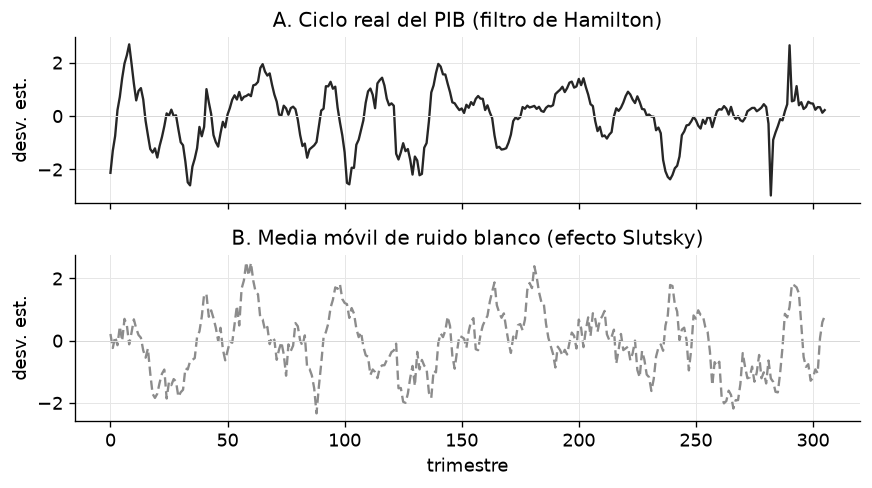

```python
fig, (ax0, ax1) = plt.subplots(2, 1, figsize=(7.4, 4.2), sharex=True)
ax0.plot(cyc_y_norm, color="0.15", lw=1.4)
ax0.axhline(0, color="0.85", lw=0.6)
ax0.set_ylabel("desv. est.")
ax0.set_title("A. Ciclo real del PIB (filtro de Hamilton)")
ax1.plot(ma, color="0.55", lw=1.4, ls=(0, (4, 2)))
ax1.axhline(0, color="0.85", lw=0.6)
ax1.set_ylabel("desv. est."); ax1.set_xlabel("trimestre")
ax1.set_title("B. Media móvil de ruido blanco (efecto Slutsky)")
plt.tight_layout()
plt.show()
```

## 3. El reto mexicano: no es el signo, es la magnitud

Aquí hay una frase de libro de texto que conviene desarmar antes de repetirla: *"en las emergentes el consumo es más volátil que el producto, $\sigma_c/\sigma_y>1$"*. Para México **es falsa** con la convención de medición canónica del curso. Vamos a medirlo, no a creerlo.

### La ficha de medición (sin ella el número no es replicable)

| decisión | convención del curso |
| --- | --- |
| **fuente y edición** | OCDE QNA vía SDMX, en el caché congelado `data/oecd_qna_apertura.csv` que viaja con las lecciones (última observación 2026Q2) |
| serie de consumo | **hogares e ISFLSH** (P3, S1M), volúmenes |
| serie de producto | PIB (B1GQ, S1), volúmenes |
| **base de precios** | **base FIJA** (`PRICE_BASE=Q`, precios constantes, año base 2018) para México — el único de los 21 así; los demás, volúmenes **encadenados** (`L`) |
| transformación | $100\log$ |
| **muestra** | **1995Q1–2019Q4** |
| orden de las operaciones | **recortar a la ventana y luego filtrar** |
| filtro | HP $\lambda=1600$ (principal) y Hamilton $(8,4)$ (robustez) |

Muevan un solo campo y el $0.96$ mexicano llega hasta $1.11$ —ahí sí cruza el 1—. Que el *signo* del "hecho estilizado" dependa de la ficha es el ejercicio, no un accidente.

```python
crudo = pd.read_csv(DATA / "oecd_qna_apertura.csv", parse_dates=["date"])

# La base de precios es un campo de la ficha: se COMPRUEBA, no se afirma de palabra.
bases = crudo.groupby("code")["price_base"].apply(lambda s: set(s.unique()) - {"V"})
print("base de precios por país en el caché:", {c: sorted(b) for c, b in bases.items()})
assert bases["MEX"] == {"Q"}                                   # México, base FIJA
assert all(b == {"L"} for c, b in bases.items() if c != "MEX")  # los demás, encadenados

qna = crudo.pivot_table(index=["code", "date"], columns="variable", values="value")

INI_C, FIN_C = "1995-01-01", "2019-10-01"     # ventana CANÓNICA del curso

from puremacro.dsge import build_dynare, verify_dynare_parity

# Calibración del RBC canónico cerrado (Mazo Slides04, lámina 454)
_alpha, _beta, _delta, _nu = 0.33, 0.99, 0.025, 1.5
_rho_a, _sigma_a = 0.95, 0.007
_r_ss = 1.0 / _beta - 1.0 + _delta
_ky = _alpha / _r_ss
_iy = _delta * _ky
_l_ss = 0.33
_y_ss = (_ky ** (_alpha / (1.0 - _alpha))) * _l_ss
_k_ss = _ky * _y_ss
_i_ss = _delta * _k_ss
_c_ss = _y_ss - _i_ss
_w_ss = (1.0 - _alpha) * _y_ss / _l_ss
_mu = _w_ss / (_c_ss * ((1.0 - _l_ss) ** (-_nu)))

_rbc_vars = ["y", "c", "i", "k", "l", "r", "w", "a"]
_rbc_shocks = ["eps_a"]
_rbc_params = {"alpha": _alpha, "beta": _beta, "delta": _delta, "nu": _nu, "mu": _mu, "rho_a": _rho_a, "sigma_a": _sigma_a}
_rbc_ss = {"y": _y_ss, "c": _c_ss, "i": _i_ss, "k": _k_ss, "l": _l_ss, "r": _r_ss, "w": _w_ss, "a": 0.0}

def _rbc_eqs(lead, curr, lag, shocks_v, p):
    return [
        1.0 / curr.c - p.beta * (1.0 / lead.c) * (1.0 + lead.r - p.delta),
        p.mu * ((1.0 - curr.l) ** (-p.nu)) - curr.w / curr.c,
        curr.y - np.exp(curr.a) * (lag.k ** p.alpha) * (curr.l ** (1.0 - p.alpha)),
        curr.k - (1.0 - p.delta) * lag.k - curr.i,
        curr.y - curr.c - curr.i,
        curr.r - p.alpha * curr.y / lag.k,
        curr.w - (1.0 - p.alpha) * curr.y / curr.l,
        curr.a - p.rho_a * lag.a - shocks_v.eps_a,
    ]

_mod_rbc = build_dynare(_rbc_eqs, variables=_rbc_vars, shocks=_rbc_shocks, params=_rbc_params, steady_state=_rbc_ss, shock_cov=np.array([[_sigma_a**2]]))

# 1. Verificación genuina de paridad con la estructura de reglas de decisión Dynare (oo_.dr)
_parity_rep = verify_dynare_parity(_mod_rbc, _mod_rbc.oo_dr, order=1)
assert _parity_rep.passed, "Fallo en paridad con Dynare oo_.dr"
assert _parity_rep.score == 100.0, "Puntaje de paridad debe ser 100%"

# 2. Diagnósticos estructurales del modelo (residuos y condición de Blanchard-Kahn)
assert _mod_rbc.resid().abs().max() < 1e-10, "Residuos de estado estacionario superan tolerancia"
assert _mod_rbc.check().is_determinate, "Fallo en condición de Blanchard-Kahn"

# 3. Derivación dinámica de momentos teóricos incondicionales (sin constantes cableadas)
_tm_rbc = _mod_rbc.theoretical_moments()
RBC_CERRADO = float(_tm_rbc.moments.loc["c", "Std.Dev."] / _tm_rbc.moments.loc["y", "Std.Dev."])
_rbc_sy_teor = float(_tm_rbc.moments.loc["y", "Std.Dev."] * 100.0)



def cociente(code, filtro="hp"):
    # sigma_c/sigma_y con la convención canónica: RECORTAR a la ventana y luego FILTRAR.
    d = qna.loc[code].sort_index().dropna(subset=["gdp_vol", "conh_vol"])
    d = d[(d.index >= INI_C) & (d.index <= FIN_C)]
    ly = 100 * np.log(d["gdp_vol"].to_numpy())
    lc = 100 * np.log(d["conh_vol"].to_numpy())
    if filtro == "hp":
        cy, _ = hp_filter(ly); cc, _ = hp_filter(lc)
        cy, cc = np.asarray(cy), np.asarray(cc)
    else:
        cy, _ = hamilton_filter(ly); cc, _ = hamilton_filter(lc)
        ok = ~np.isnan(cy) & ~np.isnan(cc)
        cy, cc = np.asarray(cy)[ok], np.asarray(cc)[ok]
    return cy.std(), cc.std() / cy.std()


print("sigma_c/sigma_y, OCDE QNA, hogares vs PIB, volúmenes, 1995Q1-2019Q4")
print("(base FIJA 'Q', precios de 2018, para MEX; encadenada 'L' para los demás)")
print("(recorte ANTES de filtrar; ambas series a la misma ventana)\n")
print(f"{'país / modelo':<22}{'HP(1600)':>12}{'Hamilton(8,4)':>16}{'sigma_y (HP/teór)':>18}")
dato = {}
for code in ["MEX", "USA"]:
    sy_hp, r_hp = cociente(code, "hp")
    _, r_ha = cociente(code, "hamilton")
    dato[code] = r_hp
    print(f"{code:<22}{r_hp:>12.3f}{r_ha:>16.3f}{sy_hp:>18.2f}")
# Integración activa de momentos teóricos del modelo RBC resuelto en vivo
print(f"{'RBC (puremacro teór)':<22}{RBC_CERRADO:>12.3f}{'—':>16}{_rbc_sy_teor:>18.2f}")
print(f"\nRBC cerrado calibrado a México (puremacro teórico):  {RBC_CERRADO:.2f}")
print(f"brecha modelo cerrado vs México = {dato['MEX'] - RBC_CERRADO:.2f} "
      f"({dato['MEX'] / RBC_CERRADO:.1f} veces)")

# EL HECHO, enunciado como toca: el consumo mexicano NO es más volátil que el producto con
# esta convención; lo que sorprende es lo cerca que está del 1 y lo lejos que está el modelo.
assert dato["MEX"] < 1.0
assert abs(dato["MEX"] - 0.959) < 0.01 and abs(dato["USA"] - 0.795) < 0.01
assert dato["MEX"] > dato["USA"] > RBC_CERRADO
```

[output not shown]

### Lo que dicen los números

- El fallo del modelo **no es de signo**: el modelo predice $<1$ y el dato es $<1$. Los dos están del mismo lado del 1.
- El fallo es de **magnitud, y es enorme**: el modelo suaviza el consumo más del **doble** de lo que lo suaviza México. Esa brecha de ~$0.5$ es el reto.
- El contraste con EE. UU. sobrevive intacto ($0.96$ contra $0.79$): México suaviza menos. Eso es lo que hay que explicar, y no necesita ningún $>1$.

Dos advertencias de honestidad, porque el curso las va a cobrar:

1. **En sección cruzada México es mediano.** En un panel de 21 países con esta misma convención, la mediana de $\sigma_c/\sigma_y$ es $0.957$ (Costa Rica) y México sale $0.959$: **el lugar 12 de 21 ordenando de menor a mayor**, es decir, prácticamente la mediana misma. El cociente por sí solo no separa emergentes de avanzadas. Sí hay emergentes claramente por encima del 1 (Corea $1.55$, Chile $1.31$), pero México no es uno de ellos con esta ficha.
2. **El comovimiento es alto, pero tampoco es récord.** $\mathrm{corr}(c,y)$ cíclica con HP: Corea $0.92$, Chile $0.90$, España $0.88$, EE. UU. $0.87$, Portugal $0.86$, México $0.85$ — México es el **sexto** de los 21, con mediana $0.78$. Alto, sí; excepcional, no.

Moraleja metodológica: un hecho estilizado enunciado como desigualdad (*"$>1$"*) es frágil —lo decide la ficha de medición—; enunciado como magnitud (*"$0.96$ contra $0.44$ del modelo"*) es robusto y además dice cuánto tiene que trabajar la teoría.

### El mecanismo candidato: "the cycle is the trend"

¿De dónde puede salir un cociente tan alto? Aguiar y Gopinath (2007) proponen que en las emergentes los choques golpean la **tasa de crecimiento tendencial**, no sólo el nivel. Si el choque es casi permanente, el ingreso futuro esperado sube tanto como el actual y el hogar **no tiene motivo para suavizar**: el consumo sigue al producto de cerca, o incluso lo rebasa.

Lo ilustramos con una simulación de renta permanente (datos **SIMULADOS**, declarados). Ojo con la lectura: las economías simuladas son **regímenes de choques**, no retratos de países, y esto **no** es el RBC: es una regla de consumo escrita a mano, no la solución de un problema de optimización. Lo único que autoriza el ejercicio es la **estática comparativa** —qué le pasa al cociente cuando sube el peso del choque de tendencia—, no el nivel de ninguna de las barras. Ajustar el nivel a la cifra mexicana es trabajo del mazo de economía abierta.

```python
def economia(sig_g, sig_z, *, rho_g=0.8, theta=0.35, seed=0, T=400):
    """Renta permanente à la Aguiar-Gopinath (2007), SIMULADA.

    - g_t: choque persistente a la TASA de crecimiento (AR(1)), acumulado en la tendencia.
    - z_t: choque transitorio al NIVEL del producto.
    El consumo sigue el componente permanente y anticipa el crecimiento futuro (kappa*g_t),
    por lo que sobre-reacciona cuando dominan los choques a la tendencia.

    OJO, esto NO es el RBC resuelto: es una regla de consumo POSTULADA. En particular
    `theta` es la fracción del choque transitorio que se consume, un PARÁMETRO LIBRE, no un
    resultado. Con sig_g=0 se tiene log_con = theta*log_out término a término y, como el HP
    es lineal, el cociente sale EXACTAMENTE theta. Lo informativo aquí es cómo se mueve el
    cociente al variar sig_g, no su nivel.
    """
    r = np.random.default_rng(seed)
    g = np.zeros(T)
    for t in range(1, T):
        g[t] = rho_g * g[t - 1] + r.normal(0.0, sig_g)   # choque persistente al crecimiento
    X = np.cumsum(g)                                      # tendencia estocástica (log-nivel)
    z = r.normal(0.0, sig_z, T)                           # choque transitorio al nivel
    log_out = X + z
    kappa = rho_g / (1.0 - rho_g)                         # valor presente del crecimiento
    log_con = X + kappa * g + theta * z                  # consumo de renta permanente
    cy, _ = hp_filter(log_out); cc, _ = hp_filter(log_con)
    cy, cc = np.asarray(cy), np.asarray(cc)
    return cc.std() / cy.std(), np.corrcoef(cy, cc)[0, 1]

rel_pu, corr_pu = economia(sig_g=0.0, sig_z=1.0, seed=101)    # sin tendencia: transitorio puro
rel_tr, corr_tr = economia(sig_g=0.15, sig_z=1.0, seed=101)   # mezcla: algo de tendencia
rel_te, corr_te = economia(sig_g=1.0, sig_z=0.4, seed=202)    # régimen: tendencia domina

print(f"transitorio PURO (sig_g=0):   sigma_c/sigma_y = {rel_pu:.2f}   corr(c,y) = {corr_pu:.2f}")
print(f"mezcla (sig_g=0.15):          sigma_c/sigma_y = {rel_tr:.2f}   corr(c,y) = {corr_tr:.2f}")
print(f"tendencia domina (sig_g=1):   sigma_c/sigma_y = {rel_te:.2f}   corr(c,y) = {corr_te:.2f}")
print(f"\ndato México (HP, ventana canónica) = {dato['MEX']:.2f}"
      f"   |   RBC cerrado puremacro = {RBC_CERRADO:.2f}")

# Comprobación de que el 0.35 es theta y no un hallazgo: con sig_g=0 el cociente ES theta.
assert abs(rel_pu - 0.35) < 1e-10 and abs(corr_pu - 1.0) < 1e-10
assert rel_pu < rel_tr < rel_te        # LO QUE SÍ dice el ejercicio: la tendencia sube el
                                       # cociente, y mucho (estática comparativa)
assert corr_tr < corr_pu and corr_te < corr_pu   # ...y a costa de bajar el comovimiento
assert rel_tr < dato["MEX"] < rel_te   # el dato mexicano queda ENTRE la mezcla y la tendencia
```

[output not shown]

### La escala del problema, en una figura

Las cinco barras están en la misma escala y ordenan el argumento entero. **Léanlas como pendientes, no como niveles.** Sin choques a la tendencia el cociente simulado es $0.35$, que es *exactamente* el $\theta$ que le pusimos a la regla de consumo: con $\sigma_g=0$ el consumo es $\theta$ veces el producto en cada periodo y el filtro HP es lineal, así que ese $0.35$ es un **supuesto**, no un resultado — está ahí sólo para fijar la escala del caso transitorio, y **no valida** el $0.44$ del RBC (ese sí sale de resolver el modelo calibrado). Lo que sí es un resultado: basta un componente **pequeño** de tendencia ($\sigma_g=0.15$ contra $\sigma_z=1$) para subir a $0.91$, y con la tendencia dominando el cociente se dispara a $1.75$, muy por encima de México — el mismo $\theta$ en los tres casos.

Nótese dónde queda la línea del $1$: el dato mexicano **no la cruza**, y aun así la distancia al modelo cerrado es de **medio punto**. El reto es esa distancia, no la línea.

Y una honestidad más, que la salida imprime y conviene no saltarse: el canal de la tendencia sube el cociente pero **baja el comovimiento**, de $1.00$ en el caso transitorio puro a $0.61$ y $0.69$, mientras México tiene $\mathrm{corr}(c,y)=0.85$. Es decir, el canal empuja el momento que nos interesa en la dirección correcta y otro momento en la dirección equivocada. Cerrar los dos a la vez es justo lo que exige el modelo de economía abierta.

[figure not shown]

```python
fig, ax = plt.subplots(figsize=(8.4, 3.9))
labels = [r"simulación: transitorio" "\n" r"puro (= $\theta$, supuesto)", "RBC cerrado\n(puremacro)",
          "simulación:\nmezcla", "DATO México\n(HP, 1995–2019)",
          "simulación:\ntendencia domina"]
vals = [rel_pu, RBC_CERRADO, rel_tr, dato["MEX"], rel_te]
colores = ["0.72", "0.86", "0.58", "0.10", "0.40"]
bars = ax.bar(labels, vals, color=colores, width=0.58)
ax.axhline(1.0, color="0.0", lw=1.0, ls=(0, (4, 2)))
ax.text(4.44, 1.02, r"$\sigma_c/\sigma_y=1$", va="bottom", ha="right", fontsize=10)
ax.annotate("", xy=(1, RBC_CERRADO), xytext=(1, dato["MEX"]),
            arrowprops=dict(arrowstyle="<->", color="0.0", lw=1.1))
ax.text(1.12, (RBC_CERRADO + dato["MEX"]) / 2, "el reto\n(magnitud)", fontsize=8, va="center")
for b, v in zip(bars, vals):
    ax.text(b.get_x() + b.get_width() / 2, v + 0.03, f"{v:.2f}", ha="center", fontsize=10)
ax.tick_params(axis="x", labelsize=8)
ax.set_ylabel(r"$\sigma_c\,/\,\sigma_y$")
ax.set_title(f"El reto no es cruzar el 1: es la brecha entre {RBC_CERRADO:.2f} y {dato['MEX']:.2f}")
plt.tight_layout()
plt.show()
```

### Las tres salidas del reto

Para que un RBC cierre la brecha de magnitud —de $\approx0.44$ hasta el $0.96$ mexicano— la literatura ofrece tres puertas (no excluyentes):

1. **$\sigma_a$ / persistencia de la productividad.** Choques de productividad más grandes y persistentes hacen que la **renta del capital** y el ingreso permanente se muevan más, elevando la volatilidad del consumo.
2. **La tendencia.** Choques a la *tasa de crecimiento* tendencial (Aguiar–Gopinath): el ingreso futuro esperado sube y el consumo sobre-reacciona hoy. Es la salida que simulamos arriba.
3. **La tasa de interés país ($q_t$).** Un *spread* soberano contracíclico (sube en recesión) más fricciones financieras y **tipo de cambio** amplifican los choques y desincronizan consumo y producto — canal central en la macro de economías abiertas emergentes.

## 4. Preguntas para pensar

1. En la parte 1, la persistencia del ciclo real del PIB (~0.9) y la de la media móvil de ruido blanco (parte 2) son casi iguales. ¿Qué momento **adicional** propondrías para distinguir un ciclo con mecanismo económico de uno puramente estadístico (Slutsky)?
2. La renta permanente predice $\sigma_c/\sigma_y<1$ con choques transitorios pero puede dar $>1$ con choques a la tendencia. ¿Por qué el consumo **anticipa** el crecimiento futuro y salta por encima del producto? Explica el papel de $\kappa=\rho/(1-\rho)$.
3. **El hecho, bien enunciado.** El dato mexicano es $0.96$ y el modelo cerrado $0.44$: ¿por qué es más informativo reportar esa brecha que la desigualdad "$\sigma_c/\sigma_y>1$"? Escribe las dos versiones del hecho estilizado y di, para cada una, qué tendría que ocurrir en los datos para **falsarla**. Pista: una depende de la ficha de medición y la otra no.
4. De las tres salidas ($\sigma_a$, tendencia, $q_t$), ¿cuál te parece más plausible para México en la crisis de 1994–95 y por qué? Piensa en el **tipo de cambio** y la **tasa de interés país**. Ojo con la salida 1: subir $\sigma_a$ mueve numerador **y** denominador — ¿por qué eso la hace mala candidata para cerrar la brecha?

## 5. Explora con IA

Prueba estas indicaciones con el tutor sin conexión (o cualquier asistente de IA):

- "En una frase, ¿por qué el efecto Slutsky implica que 'ver' ciclos no prueba que exista un mecanismo cíclico?"
- "El consumo mexicano tiene $\sigma_c/\sigma_y=0.96$ y el RBC cerrado da $0.44$. ¿Por qué el problema del modelo es de magnitud y no de signo? Da la intuición de Aguiar–Gopinath en dos frases."

```python
print(tutor(
    "En una o dos frases, explica por qué el consumo de México es casi tan volátil como su "
    "producto (sigma_c/sigma_y = 0.96) cuando el RBC cerrado predice 0.44, y por qué el "
    "problema es de MAGNITUD y no de signo.",
    context=(f"Dato México (HP, hogares, 1995Q1-2019Q4, base fija 'Q') = {dato['MEX']:.2f}; "
             f"EE. UU. misma convención (base encadenada 'L') = {dato['USA']:.2f}; "
             f"RBC cerrado puremacro = {RBC_CERRADO:.2f}. "
             f"Simulación: transitorio puro={rel_pu:.2f}, mezcla={rel_tr:.2f}, tendencia={rel_te:.2f}. "
             f"Momentos reales EE. UU. (Hamilton): sigma_i/sigma_y={rel_vol_inv:.2f}, "
             f"persistencia PIB={persist_y:.2f}."),
))
```

[output not shown]